# CSCI E-63C Problem Set 9

# Preface

For this week problem set we will use WiFi localization data (the one we worked with on week 2) to fit logistic regression model and evaluate performance of LDA, QDA and KNN classifiers. As we have seen earlier this dataset should allow to locate phones fairly well by relying on the strength of WiFi signal, so we should expect to see fairly low error rates for our classifiers. Let’s see whether some of those classifiers perform better than others on this data.

**Important note:** *For the purposes of all problems in this week problem set, we will be predicting whether the phone is at location=3 or not, as opposed to working with multi-class predictor. In other words, before you proceed with any of the problems in this assignment, please convert the four-levels outcome to the outcome with only two levels: location=3 (must be 500 of those) and not (must be 1500 of them).*

*If you are creating a new column containing this binary outcome, please make sure that the original outcome with four columns is NOT used inadvertently as one of the predictors. If you are getting invariably 100% accuracy regardless of the choice of the method or split of the data into training and test, chances are your code is using original four-levels outcome as a predictor.*

```r
library(MASS)
library(class)
library(e1071)

wifiData <- read.table("./wifi_localization.txt", header=FALSE, sep="\t")

for (i in 1:7) {
  names(wifiData)[i] <- sprintf("Signal %i", i)
}
isroom3 <- ifelse(wifiData[,8]==3, 1, 0)
isroom3 <- as.factor(isroom3)
wifiData[8] <- isroom3
colnames(wifiData)[8] <- "IsRoom3"
head(wifiData)
```

```
##   Signal 1 Signal 2 Signal 3 Signal 4 Signal 5 Signal 6 Signal 7 IsRoom3
## 1      -64      -56      -61      -66      -71      -82      -81       0
## 2      -68      -57      -61      -65      -71      -85      -85       0
## 3      -63      -60      -60      -67      -76      -85      -84       0
## 4      -61      -60      -68      -62      -77      -90      -80       0
## 5      -63      -65      -60      -63      -77      -81      -87       0
## 6      -64      -55      -63      -66      -76      -88      -83       0
```

# Problem 1 (10 points): logistic regression

Fit logistic regression model of the binary categorical outcome (location=3 or not) using seven WiFi signals strengths as predictors in the model. Produce summary of the model, describe which attributes appear to be significantly associated with the categorical outcome in this model. Use this model to make predictions on the entire dataset and compare these predictions and corresponding true values of the class attribute using confusion matrix (i.e. contingency table). Calculate error rate (would this be training or test error in this case?), sensitivity and specificity (assuming that we are predicting class “location=3”). Describe the results.

```r
logreg <- glm(IsRoom3~.,data=wifiData, family=binomial)
summary(logreg)
```

```
##
## Call:
## glm(formula = IsRoom3 ~ ., family = binomial, data = wifiData)
##
## Deviance Residuals:
##      Min        1Q    Median        3Q       Max
## -2.25602  -0.69944  -0.41966   0.06246   2.52634
##
## Coefficients:
##             Estimate Std. Error z value Pr(>|z|)
## (Intercept) -5.84266    1.53114  -3.816 0.000136 ***
## `Signal 1`   0.06149    0.01376   4.471 7.80e-06 ***
## `Signal 2`   0.11270    0.01875   6.011 1.84e-09 ***
## `Signal 3`   0.21847    0.01679  13.014  < 2e-16 ***
## `Signal 4`   0.04002    0.01324   3.022 0.002513 **
## `Signal 5`  -0.13188    0.01061 -12.427  < 2e-16 ***
## `Signal 6`  -0.12960    0.01590  -8.153 3.56e-16 ***
## `Signal 7`  -0.11333    0.01425  -7.952 1.83e-15 ***
## ---
## Signif. codes:  0 '***' 0.001 '**' 0.01 '*' 0.05 '.' 0.1 ' ' 1
##
## (Dispersion parameter for binomial family taken to be 1)
##
##     Null deviance: 2249.3  on 1999  degrees of freedom
## Residual deviance: 1792.0  on 1992  degrees of freedom
## AIC: 1808
##
## Number of Fisher Scoring iterations: 5
```

**According to the logistic regression model sumamry, all variables may have some predictive value in categorizing the room (room 3 or not). It appears that signals 3 and 5 are most influential in prediction.**

```r
logreg.probs <- predict(logreg, type="response")
logreg.pred <- rep(0, 2000)
logreg.pred[logreg.probs > 0.5] <- 1
logreg.confmatrix <- table(logreg.pred, wifiData$IsRoom3)
logreg.confmatrix
```

```
##
## logreg.pred    0    1
##           0 1385  322
##           1  115  178
```

```r
logreg.error <- 1-mean(logreg.pred==wifiData$IsRoom3)
logreg.error
```

```
## [1] 0.2185
```

```r
logreg.specificity <- 1385/(115+1385)
logreg.specificity
```

```
## [1] 0.9233333
```

```r
logreg.sensitivity <- 178/(322+178)
logreg.sensitivity
```

```
## [1] 0.356
```

# Problem 2 (10 points): LDA and QDA

Using LDA and QDA implementations available in the package `MASS`, fit LDA and QDA classifiers on the entire dataset and calculate confusion matrix, (training) error rate, sensitivity and specificity for each of them. Compare them to those of logistic regression. Describe the results.

```r
lda.fit <- lda(IsRoom3~., data=wifiData)
lda.preds <- predict(lda.fit)
lda.confmatrix <- table(lda.preds$class, wifiData$IsRoom3)
lda.confmatrix
```

```
##
##        0    1
##   0 1382  321
##   1  118  179
```

```r
lda.error <- 1-mean(lda.preds$class==wifiData$IsRoom3)
lda.error
```

```
## [1] 0.2195
```

```r
lda.specificity <- 1382/(118+1382)
lda.specificity
```

```
## [1] 0.9213333
```

```r
lda.sensitivity <- 179/(179+321)
lda.sensitivity
```

```
## [1] 0.358
```

# Problem 3 (10 points): KNN

Using `knn` from library `class`, fit KNN classifiers for the entire dataset and calculate confusion matrix, (training) error rate, sensitivity/specificity for $k=1$, $5$ and $25$ nearest neighbors models. Compare them to the corresponding results from LDA, QDA and logistic regression. Describe results of this comparison and discuss whether it is surprising to see low *training* error for KNN classifier with $k=1$.

```r
for (i in c(1, 5, 25)) {
  knn.fit <- knn(train=wifiData, test=wifiData, cl=wifiData$IsRoom3, k=i)
  knn.table <- table(knn.fit, wifiData$IsRoom3)
  print(knn.table)
  knn.error <- 1-mean(knn.fit==wifiData$IsRoom3)
  print(knn.error)
  knn.specificity <- knn.table[1,1] / sum(knn.table[,1])
  print(knn.specificity)
  knn.sensitivity <- knn.table[2,2] / sum(knn.table[,2])
  print(knn.sensitivity)
}
```

```
##
## knn.fit    0    1
##       0 1500    0
##       1    0  500
## [1] 0
## [1] 1
## [1] 1
##
## knn.fit    0    1
##       0 1490    5
##       1   10  495
## [1] 0.0075
## [1] 0.9933333
## [1] 0.99
##
## knn.fit    0    1
##       0 1473    9
##       1   27  491
## [1] 0.018
## [1] 0.982
## [1] 0.982
```

**Above are the prediction results of knn models with 1, 5, and 25 clusters respectively. The accuracy rate, specificity, and sensitivity across the board are higher than the previous models. However, I suspect there is serious bias when using the same data on training and test. For example, with one neighbor, the knn algorithm actually chooses itself as the nearest neighbor, meaning there will be no training error.**

# Problem 4 (30 points): compare test errors of logistic regression, LDA, QDA and KNN

Using resampling approach of your choice (e.g. cross-validation, bootstrap, etc.) obtain test error as well as sensitivity and specificity for each of these methods (logistic regression, LDA, QDA, KNN with $k=1,7,55,351$). Present results in the form of boxplots, compare test error/sensitivity/specificity across these methods and discuss their relative performance.

```r
for ( iTry in 1:10 ) {
  cat("Trial",iTry,"- GLM, LDA, QDA, knn: k=1, k=7, k=55, k=351\n")
  trainIdx <- sample(nrow(wifiData),nrow(wifiData),replace=TRUE)
  wTrain <- wifiData[trainIdx,]
  wTest <- wifiData[-trainIdx,]
  logTry <- glm(IsRoom3~.,data=wTrain,family=binomial)
  ldaTry <- lda(IsRoom3~.,data=wTrain)
  qdaTry <- qda(IsRoom3~.,data=wTrain)
  glmTestRes <- as.numeric(predict(logTry,newdata=wTest,type="response")>0.5)
  ldaTestRes <- predict(ldaTry,newdata=wTest)$class
  qdaTestRes <- predict(qdaTry,newdata=wTest)$class
  # boxplot(glmTestRes~wTest[,"IsRoom3"])
  # boxplot(ldaTestRes~wTest[,"IsRoom3"])
  # boxplot(qdaTestRes~wTest[,"IsRoom3"])
  tblTstglm <- table(wTest[,"IsRoom3"],glmTestRes)
  tblTstLDA <- table(wTest[,"IsRoom3"],ldaTestRes)
  tblTstQDA <- table(wTest[,"IsRoom3"],qdaTestRes)

  glm.specificity <- tblTstglm[1,1] / sum(tblTstglm[,1])
  glm.sensitivity <- tblTstglm[2,2] / sum(tblTstglm[,2])

  LDA.specificity <- tblTstLDA[1,1] / sum(tblTstLDA[,1])
  LDA.sensitivity <- tblTstLDA[2,2] / sum(tblTstLDA[,2])

  QDA.specificity <- tblTstQDA[1,1] / sum(tblTstQDA[,1])
  QDA.sensitivity <- tblTstQDA[2,2] / sum(tblTstQDA[,2])

  knn1.fit <- knn(train=wTrain, test=wTest, cl=wifiData$IsRoom3, k=1)
  knn1.table <- table(wTest[,"IsRoom3"], knn1.fit)
  knn1.error <- 1-mean(knn1.fit==wTest$IsRoom3)
  knn1.specificity <- knn1.table[1,1] / sum(knn1.table[,1])
  knn1.sensitivity <- knn1.table[2,2] / sum(knn1.table[,2])

  knn7.fit <- knn(train=wTrain, test=wTest, cl=wifiData$IsRoom3, k=7)
  knn7.table <- table(wTest[,"IsRoom3"], knn7.fit)
  knn7.error <- 1-mean(knn7.fit==wTest$IsRoom3)
  knn7.specificity <- knn7.table[1,1] / sum(knn7.table[,1])
  knn7.sensitivity <- knn7.table[2,2] / sum(knn7.table[,2])

  knn55.fit <- knn(train=wTrain, test=wTest, cl=wifiData$IsRoom3, k=55)
  knn55.table <- table(wTest[,"IsRoom3"], knn55.fit)
  knn55.error <- 1-mean(knn55.fit==wTest$IsRoom3)
  knn55.specificity <- knn55.table[1,1] / sum(knn55.table[,1])
  knn55.sensitivity <- knn55.table[2,2] / sum(knn55.table[,2])

  knn351.fit <- knn(train=wTrain, test=wTest, cl=wifiData$IsRoom3, k=351)
  knn351.table <- table(wTest[,"IsRoom3"], knn351.fit)
  knn351.error <- 1-mean(knn351.fit==wTest$IsRoom3)
  knn351.specificity <- knn351.table[1,1] / sum(knn351.table[,1])
  knn351.sensitivity <- knn351.table[2,2] / sum(knn351.table[,2])

  print("Error rates:")
  cat(1-sum(diag(tblTstglm))/sum(tblTstglm),1-sum(diag(tblTstLDA))/sum(tblTstLDA),1-sum(diag(tblTstQDA))/sum(tblTstQDA), knn1.error, knn7.error, knn55.error, knn351.error,fill=TRUE)

  print("Specificity:")
  cat(glm.specificity,LDA.specificity, QDA.specificity, knn1.specificity, knn7.specificity, knn55.specificity, knn351.specificity,fill=TRUE)

  print("Sensitivity:")
  cat(glm.sensitivity,LDA.sensitivity, QDA.sensitivity, knn1.sensitivity, knn7.sensitivity, knn55.sensitivity, knn351.sensitivity,fill=TRUE, "\n\n")
}
```

```
## Trial 1 - GLM, LDA, QDA, knn: k=1, k=7, k=55, k=351
## [1] "Error rates:"
## 0.2297477 0.2284197 0.03984064 0.377158 0.2815405 0.247012 0.247012
## [1] "Specificity:"
## 0.7975831 0.7987897 0.9574106 0.746087 0.7524893 0.752988 0.752988
## [1] "Sensitivity:"
## 0.5714286 0.576087 0.9698795 0.2247191 0.24 NaN NaN
##
##
## Trial 2 - GLM, LDA, QDA, knn: k=1, k=7, k=55, k=351
## [1] "Error rates:"
## 0.2255435 0.2255435 0.02853261 0.3627717 0.2581522 0.2459239 0.2459239
## [1] "Specificity:"
## 0.8132045 0.817292 0.9700704 0.7580645 0.7664234 0.7540761 0.7540761
## [1] "Sensitivity:"
## 0.5652174 0.5609756 0.9761905 0.258427 0.4117647 NaN NaN
##
##
## Trial 3 - GLM, LDA, QDA, knn: k=1, k=7, k=55, k=351
## [1] "Error rates:"
## 0.2253333 0.22 0.036 0.396 0.2893333 0.2506667 0.2506667
## [1] "Specificity:"
## 0.8055988 0.8135861 0.9620035 0.7336861 0.7518248 0.7493333 0.7493333
## [1] "Sensitivity:"
## 0.588785 0.5982906 0.9707602 0.2021858 0.2769231 NaN NaN
##
##
## Trial 4 - GLM, LDA, QDA, knn: k=1, k=7, k=55, k=351
## [1] "Error rates:"
## 0.25 0.25 0.05107527 0.3965054 0.2930108 0.2607527 0.2607527
## [1] "Specificity:"
## 0.7879747 0.7888889 0.9429066 0.7225131 0.7412791 0.7392473 0.7392473
## [1] "Sensitivity:"
## 0.5357143 0.5350877 0.9698795 0.2046784 0.2857143 NaN NaN
##
##
## Trial 5 - GLM, LDA, QDA, knn: k=1, k=7, k=55, k=351
## [1] "Error rates:"
## 0.2032301 0.204576 0.03768506 0.3526245 0.2745626 0.2368775 0.2368775
## [1] "Specificity:"
```

[output cut: 33 more lines]

```
## [1] "Error rates:"
## 0.2324037 0.2363878 0.03984064 0.3559097 0.2828685 0.2430279 0.2430279
## [1] "Specificity:"
## 0.814992 0.8141026 0.9560811 0.7594502 0.7568345 0.7569721 0.7569721
## [1] "Sensitivity:"
## 0.531746 0.5193798 0.9751553 0.251462 0.2413793 NaN NaN
##
##
## Trial 10 - GLM, LDA, QDA, knn: k=1, k=7, k=55, k=351
## [1] "Error rates:"
## 0.2105263 0.2160665 0.02908587 0.3559557 0.3157895 0.2465374 0.2465374
## [1] "Specificity:"
## 0.8234323 0.8211921 0.964476 0.746988 0.7401216 0.7534626 0.7534626
## [1] "Sensitivity:"
## 0.612069 0.5932203 0.9937107 0.2198582 0.109375 NaN NaN
```

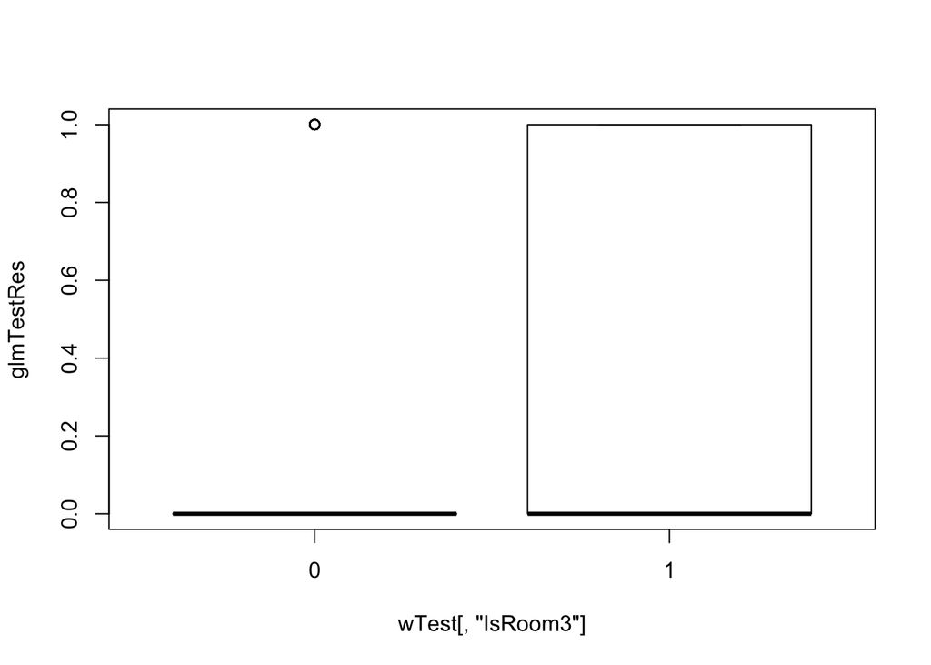

```r
boxplot(glmTestRes~wTest[,"IsRoom3"])
```

Apologies for the extremely unmodular code. I was also unable to generate boxplots for most of the methods and found the prediction-based plot for the glm model to not add any value (I may have done it wrong) so I included just one at the end.

# Extra 5 points problem: naive Bayes classifier

Fit naive Bayes classifier (see lecture slides for examples of using `naiveBayes` function from package `e1071`) to the WiFi localization dataset with binary (location=3 or not) outcome and assess its performance on test data by resampling along with logistic regression, LDA, QDA and KNN in the Problem 4 above.

# Extra 10 points problem: interaction terms in logistic regression

Add pairwise interaction terms to the logistic regression model fit in the Problem 1 above and evaluate impact of their addition on training **and** test error. You can add all pairwise interaction terms or a subset of them, in which case the rationale behind selecting such a subset has to be described in your solution.